# 1. Broad Analysis

5 Juni 2019

The goal of the following broad analysis is to gain an overview of the given datasets containing the influence of different drugs to the cellular response. This will be the basis for all next investigations, containing one specific drug - cisplatin.

```r
library(viridis)
library(ggplot2)
```

## Table of content

1. Cleaning up our data - NAs and scaling
2. Plotting the gene expression unscaled and scaled
3. Computation of the Fold Change - Treated/Untreated
4. Principal component analysis between treated and untreated data  
   4.1 Colored PCA - drugs  
   4.2 Colored PCA - chemo/targeted  
   4.3 Colored PCA - tyrosine kinase inhibitor

## 1. Cleaning up our data - NAs and scaling

In order to clean up our data, a loop for checking the amount of NAs in every matrix was created. Rows/Columns containing only NAs were deleted, because they do not contain any information. This only concerned the “mutations” matrix, and two columns were deleted. Furthermore the data has been scaled for the following investigations.

## 2. Plotting the gene expression unscaled and scaled

In order to get an overview, a boxplot of the treated data was computed and every drug was colored in a different color. There were 15 different batches visible, so another boxplot with the scaled data from treated was computed. The batches dissapeared due to the fact that through scaling, all irregularitys in measuring and experimental conditions were removed.

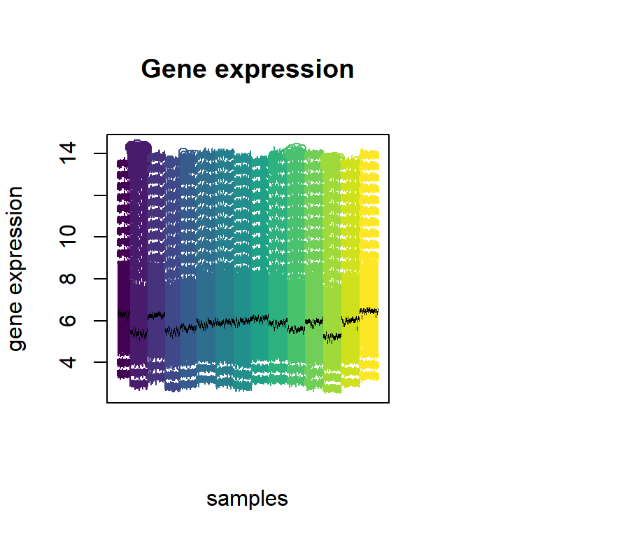

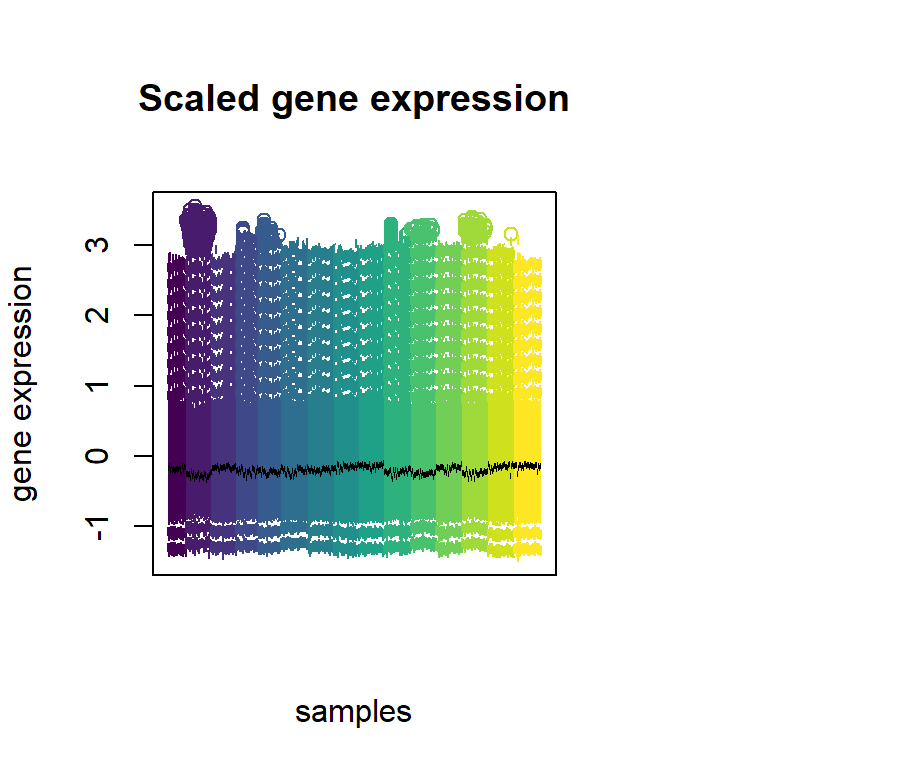

## 3. Computation of the Fold Change - Treated/Untreated

In order to analyse the gene expression change from untreated to treated, log2 fold change values were computed. Because the data given was already log2-transformed, computing the difference between the treated(scaled) and untreated(scaled) data was enough. The distribution of the fold change values was checked through a density plot. The values are normally distributed and located near to 0. In the future, it would have also been interesting to explore the density of the fold change values by each cell line and not by all cell lines together.

```r
log2FC.treated.untreated <- treated.scaled - untreated.scaled
```

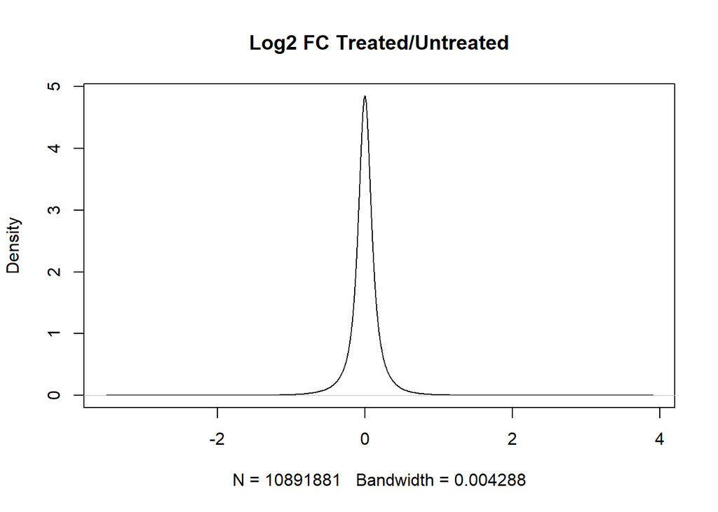

```r
plot(density(log2FC.treated.untreated), main = "Log2 FC Treated/Untreated")
```

## 4. Principal component analysis between treated and untreated data

For a dimensionallity reduction, a principal component analysis was performed. Component 4 was chosen as the last significant component, regarding to the elbow plot.

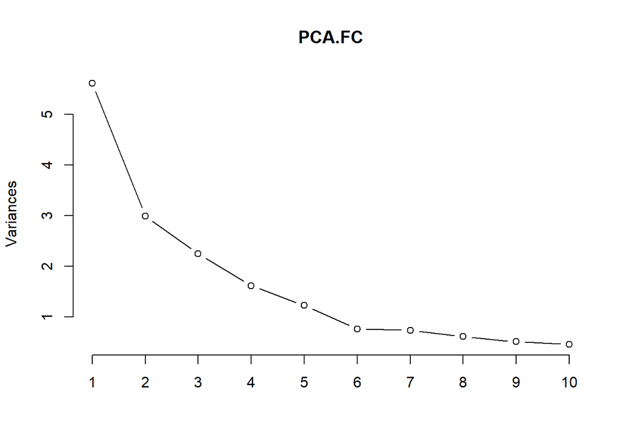

```r
PCA.FC <- prcomp(log2FC.treated.untreated, center=F , scale.=F)
plot(PCA.FC, type ="lines")
```

The PCA was interpreted by plotting the first four components in different plots, and coloring different groups of data.

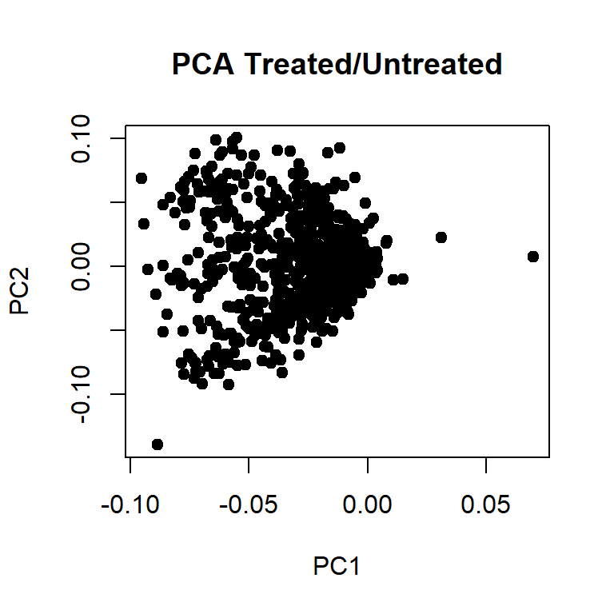

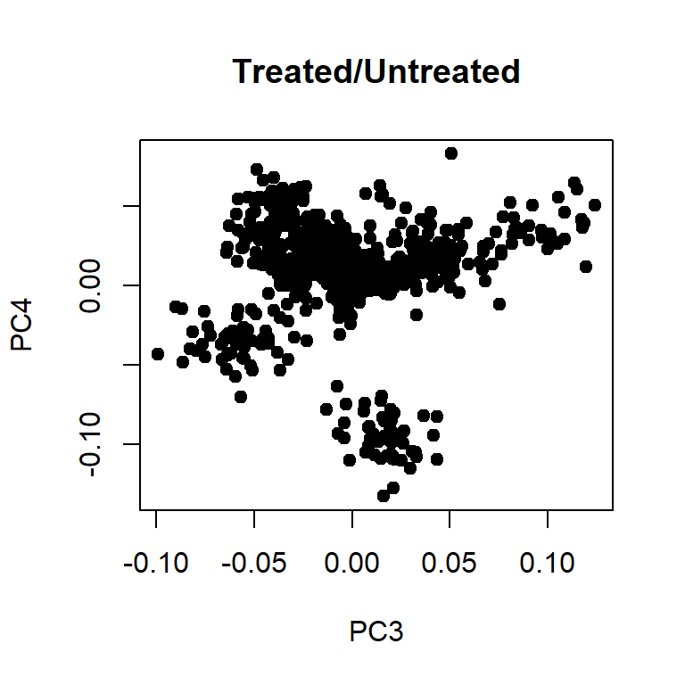

### 4.1 Colored PCA - drugs

Firstly, each drug was colored in a different color. PC1 and PC2 don’t seem to show any separations, but PC3 and PC4 seem to seperate the diffenrent drugs, especially Vorinostat an Bortezomib.

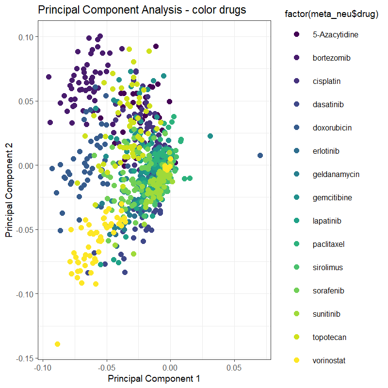

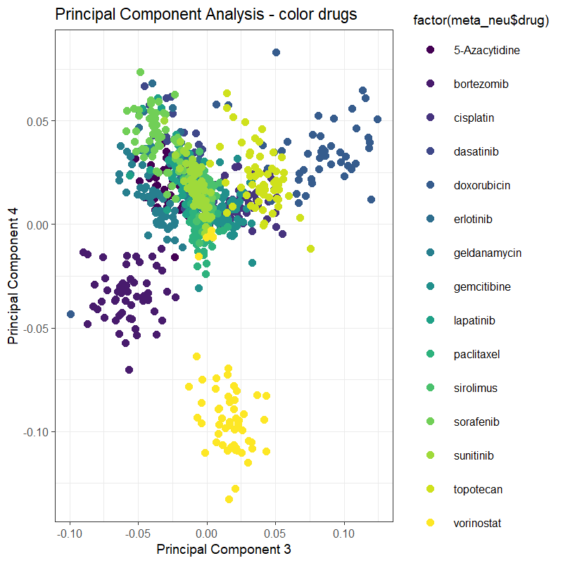

```r
pca_plot_drugs12
pca_plot_drugs34
```

This could be because vorinostat is the only HDAC inhibitor. It is a cytostatic drug used in T-cell lymphomas and therefor it is very specific. Bortezomib is the only Proteasome inhibitor and causes the loss of function of the proteasom. The loss of function of the proteasome results in the inhibition of different proteins, what leads to apoptosis and downregulation of the cell cycle.

### 4.2 Colored PCA - chemo/targeted

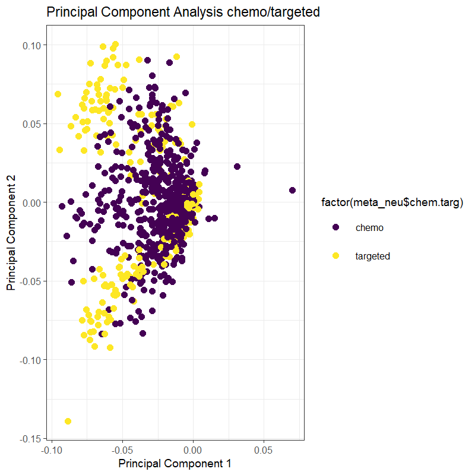

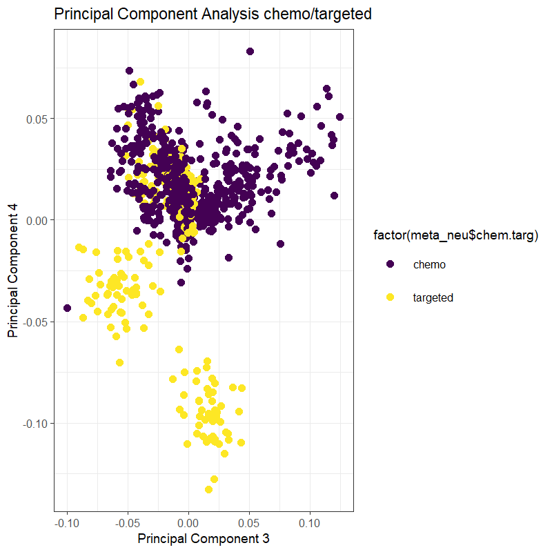

```r
pca_plot_chemtarg12
pca_plot_chemtarg34
```

### 4.3 Colored PCA - tyrosine kinase inhibitor

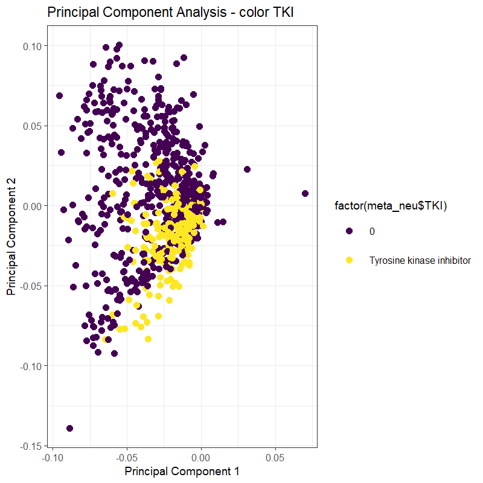

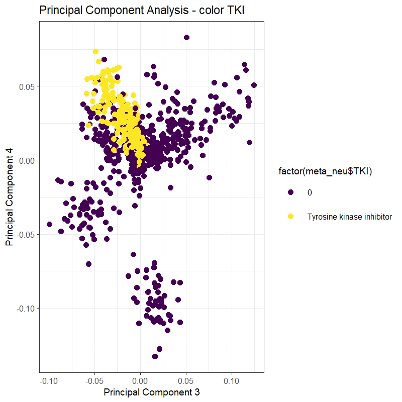

```r
pca_plot_TKI12
pca_plot_TKI34
```